# Analysis of Internet Usage and Female Labor Force Participation

November 4, 2025

### Introduction

This document analyzes the relationship between the percentage of the population using the internet and the female labor force participation rate across different countries for the year 2022. The data is sourced from the World Bank.

### Research Question and Hypothesis

**Research Question:** Is there a relationship between internet usage and female labor force participation rates across countries?

**Hypothesis:** We expect to find a **positive relationship** between internet usage and female labor force participation. Our reasoning:

1. **Access to opportunities:** Internet access provides women with better access to job opportunities, including remote work positions that may not be available locally.
2. **Flexibility:** Online platforms and digital tools enable flexible work arrangements that can help women balance work and family responsibilities more effectively.
3. **Economic development:** Higher internet usage is typically associated with more developed economies, which tend to have more gender-equal labor markets and better infrastructure supporting women’s workforce participation.
4. **Education and skills:** Internet access facilitates online education and skill development, potentially increasing women’s employability.

However, we acknowledge that this relationship may be complex and influenced by many cultural, economic, and social factors that vary across countries.

### 1. Data Preparation

First, we load the necessary libraries. We will be using the `tidyverse` package for data manipulation and visualization, and the `WDI` package to download data directly from the World Bank.

```r
# install.packages("tidyverse") # Run this line if you don't have tidyverse installed
# install.packages("WDI") # Run this line if you don't have WDI installed
library(tidyverse)
library(WDI)
```

Now, we download the data directly from the World Bank using the WDI package. We need two indicators: - IT.NET.USER.ZS: Internet usage (% of population) - SL.TLF.CACT.FE.ZS: Female labor force participation rate (%)

```r
# Define the indicators we want to download
indicators <- c("IT.NET.USER.ZS", "SL.TLF.CACT.FE.ZS")

# Download the data from the World Bank for the year 2022
wb_data <- WDI(country = "all",
               indicator = indicators,
               start = 2022,
               end = 2022,
               extra = TRUE)

# Prepare the data
final_data <- wb_data %>%
  select(country, IT.NET.USER.ZS, SL.TLF.CACT.FE.ZS) %>%
  rename(Country.Name = country,
         internet_usage = IT.NET.USER.ZS,
         female_labor_force = SL.TLF.CACT.FE.ZS) %>%
  na.omit()

# Display the first few rows of the final dataset
head(final_data)
```

```
##                  Country.Name internet_usage female_labor_force
## 1                 Afghanistan        17.1917            5.15900
## 2 Africa Eastern and Southern        30.2000           60.44514
## 3  Africa Western and Central        36.9000           64.73852
## 4                     Albania        82.6137           53.18300
## 5                     Algeria        74.8319           14.09200
## 8                      Angola        42.0719           73.17900
```

### 2. Descriptive Statistics

Here we calculate the basic descriptive statistics for our two variables of interest. This includes the mean, median, min, max, quartiles, variance, range, and interquartile range.

```r
# Create a nice summary table
desc_stats <- data.frame(
  Statistic = c("Mean", "Median", "Std. Deviation", "Variance", "Minimum", "Maximum", "Range", "IQR"),
  Internet_Usage = c(
    round(mean(final_data$internet_usage), 2),
    round(median(final_data$internet_usage), 2),
    round(sd(final_data$internet_usage), 2),
    round(var(final_data$internet_usage), 2),
    round(min(final_data$internet_usage), 2),
    round(max(final_data$internet_usage), 2),
    round(diff(range(final_data$internet_usage)), 2),
    round(IQR(final_data$internet_usage), 2)
  ),
  Female_Labor_Force = c(
    round(mean(final_data$female_labor_force), 2),
    round(median(final_data$female_labor_force), 2),
    round(sd(final_data$female_labor_force), 2),
    round(var(final_data$female_labor_force), 2),
    round(min(final_data$female_labor_force), 2),
    round(max(final_data$female_labor_force), 2),
    round(diff(range(final_data$female_labor_force)), 2),
    round(IQR(final_data$female_labor_force), 2)
  )
)

knitr::kable(desc_stats,
             col.names = c("Statistic", "Internet Usage (%)", "Female Labor Force (%)"),
             caption = "Descriptive Statistics for Both Variables",
             align = c('l', 'r', 'r'))
```

Descriptive Statistics for Both Variables

| Statistic | Internet Usage (%) | Female Labor Force (%) |
| --- | --- | --- |
| Mean | 67.73 | 50.57 |
| Median | 76.50 | 52.56 |
| Std. Deviation | 25.15 | 14.51 |
| Variance | 632.35 | 210.52 |
| Minimum | 11.00 | 5.16 |
| Maximum | 100.00 | 82.58 |
| Range | 89.00 | 77.42 |
| IQR | 40.36 | 16.20 |

### 3. Data Visualization

Visualizing the data helps us understand the distribution of each variable and identify potential outliers.

#### Histograms

Histograms show the distribution of a single variable.

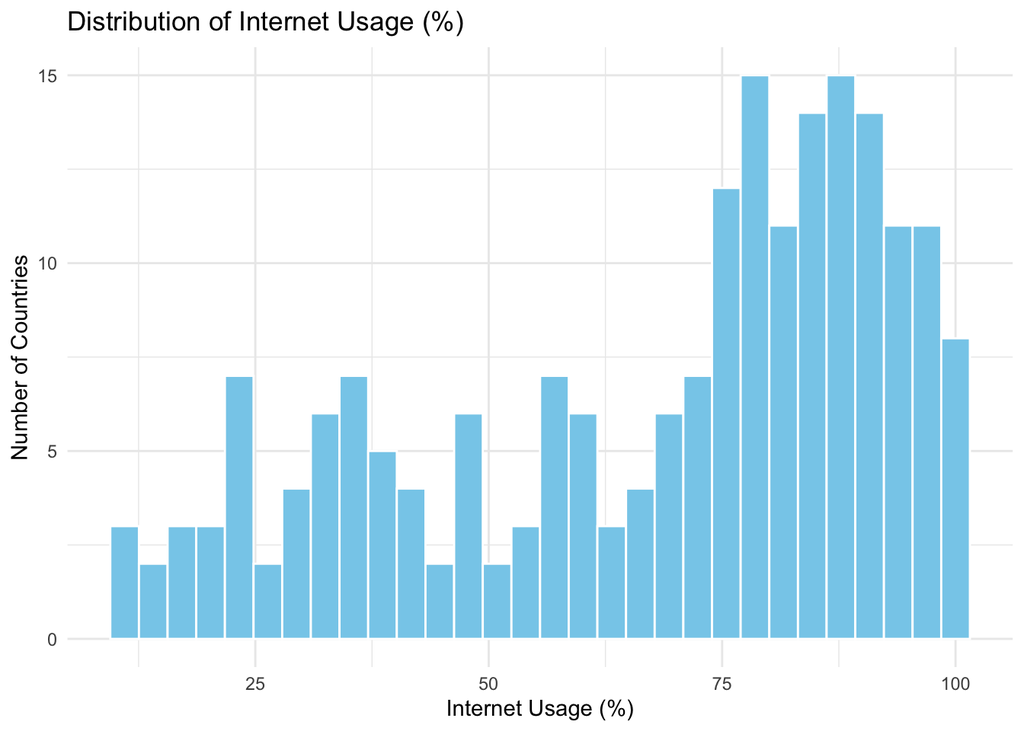

```r
# Histogram for Internet Usage
ggplot(final_data, aes(x = internet_usage)) +
  geom_histogram(bins = 30, fill = "skyblue", color = "white") +
  labs(
    title = "Distribution of Internet Usage (%)",
    x = "Internet Usage (%)",
    y = "Number of Countries"
  ) +
  theme_minimal()
```

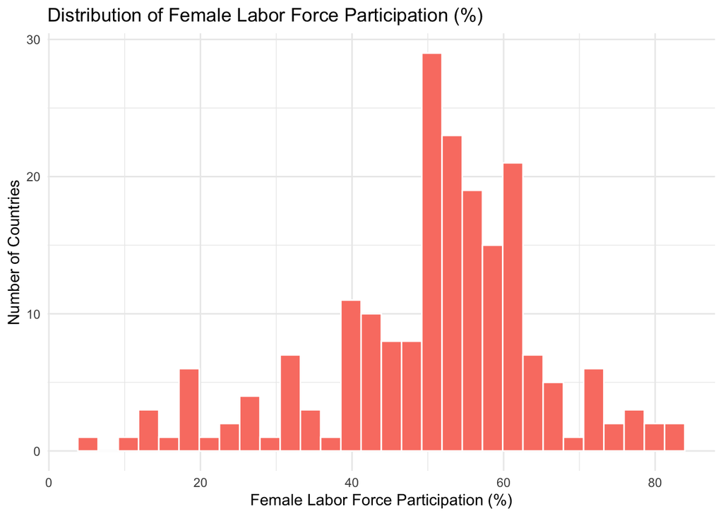

```r
# Histogram for Female Labor Force Participation
ggplot(final_data, aes(x = female_labor_force)) +
  geom_histogram(bins = 30, fill = "salmon", color = "white") +
  labs(
    title = "Distribution of Female Labor Force Participation (%)",
    x = "Female Labor Force Participation (%)",
    y = "Number of Countries"
  ) +
  theme_minimal()
```

#### Box Plots

Box plots are useful for identifying outliers and seeing the spread of the data.

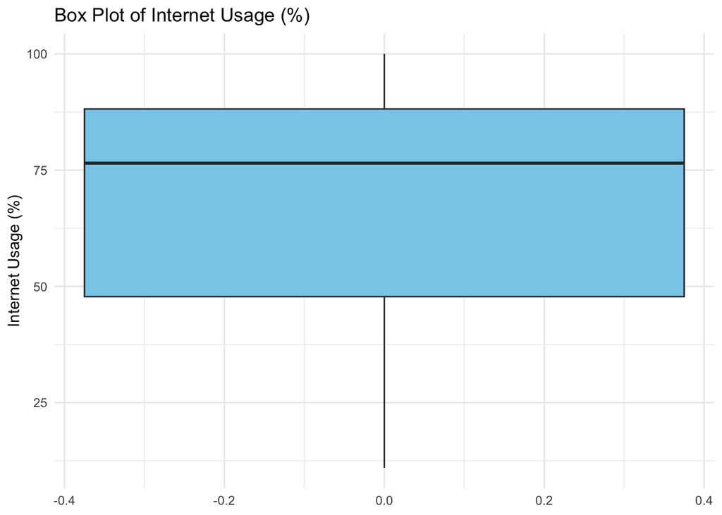

```r
# Box plot for Internet Usage
ggplot(final_data, aes(y = internet_usage)) +
  geom_boxplot(fill = "skyblue") +
  labs(
    title = "Box Plot of Internet Usage (%)",
    y = "Internet Usage (%)"
  ) +
  theme_minimal()
```

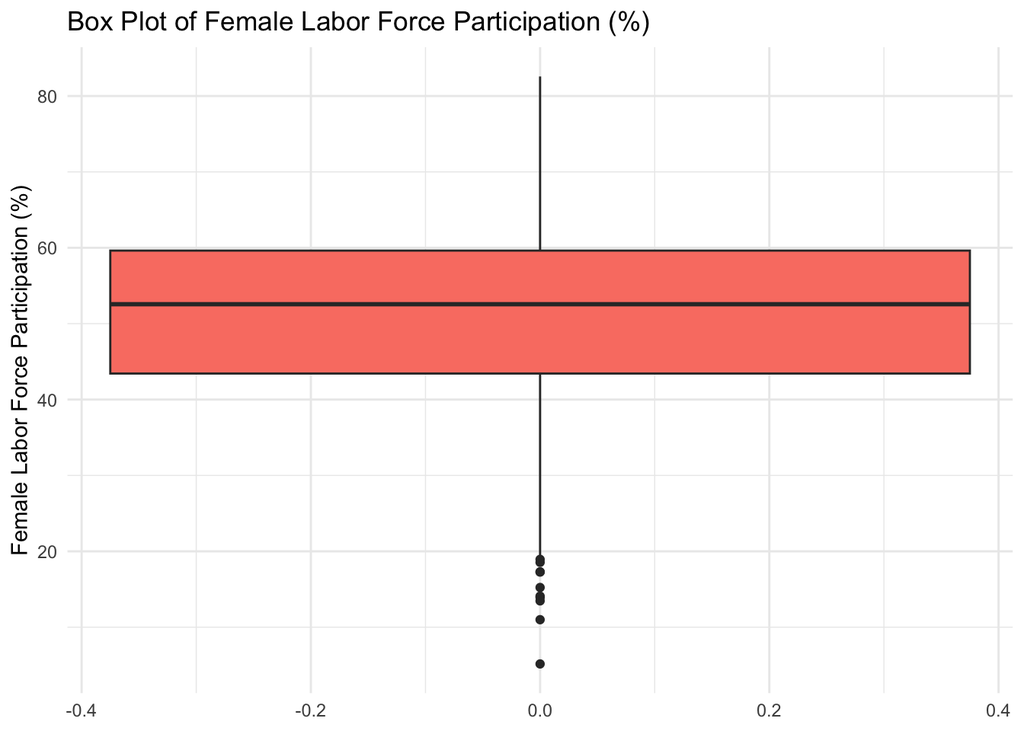

```r
# Box plot for Female Labor Force Participation
ggplot(final_data, aes(y = female_labor_force)) +
  geom_boxplot(fill = "salmon") +
  labs(
    title = "Box Plot of Female Labor Force Participation (%)",
    y = "Female Labor Force Participation (%)"
  ) +
  theme_minimal()
```

**Interpretation:** The box plots reveal several outliers. For female labor force participation, there are countries with extremely low values (below 20%), which may represent countries with significant cultural or legal barriers to women’s workforce participation.

### 4. Extreme Values Analysis

We identify and examine extreme values (outliers) in our dataset using the IQR method.

```r
# Function to detect outliers using IQR method
detect_outliers <- function(x) {
  q1 <- quantile(x, 0.25)
  q3 <- quantile(x, 0.75)
  iqr <- q3 - q1
  lower_bound <- q1 - 1.5 * iqr
  upper_bound <- q3 + 1.5 * iqr
  return(x < lower_bound | x > upper_bound)
}

# Detect outliers for internet usage
internet_outliers <- final_data[detect_outliers(final_data$internet_usage), ]
if(nrow(internet_outliers) > 0) {
  internet_outliers_sorted <- internet_outliers[order(internet_outliers$internet_usage),
                                                 c("Country.Name", "internet_usage", "female_labor_force")]
  knitr::kable(internet_outliers_sorted,
               col.names = c("Country", "Internet Usage (%)", "Female Labor Force (%)"),
               caption = "Countries with Extreme Internet Usage Values",
               row.names = FALSE,
               align = c('l', 'r', 'r'))
}

# Detect outliers for female labor force
labor_outliers <- final_data[detect_outliers(final_data$female_labor_force), ]
if(nrow(labor_outliers) > 0) {
  labor_outliers_sorted <- labor_outliers[order(labor_outliers$female_labor_force),
                                          c("Country.Name", "internet_usage", "female_labor_force")]
  knitr::kable(labor_outliers_sorted,
               col.names = c("Country", "Internet Usage (%)", "Female Labor Force (%)"),
               caption = "Countries with Extreme Female Labor Force Participation Values",
               row.names = FALSE,
               align = c('l', 'r', 'r'))
}
```

Countries with Extreme Female Labor Force Participation Values

| Country | Internet Usage (%) | Female Labor Force (%) |
| --- | --- | --- |
| Afghanistan | 17.1917 | 5.15900 |
| Iraq | 78.7156 | 10.99000 |
| Iran, Islamic Rep. | 79.0610 | 13.46900 |
| Jordan | 90.5000 | 13.92200 |
| Algeria | 74.8319 | 14.09200 |
| Egypt, Arab Rep. | 72.1981 | 15.23300 |
| Middle East, North Africa, Afghanistan & Pakistan (IDA & IBRD) | 52.0000 | 17.27636 |
| Middle East, North Africa, Afghanistan & Pakistan (excluding high income) | 52.3000 | 17.28747 |
| Djibouti | 63.2573 | 18.54600 |
| West Bank and Gaza | 88.6469 | 18.93400 |

**Interpretation:** The extreme values analysis reveals countries that deviate significantly from the typical patterns. Countries with extremely low female labor force participation (below 20%) often represent nations with specific cultural, religious, or economic factors that limit women’s workforce participation. These outliers are important to identify as they may have disproportionate influence on our correlation analysis.

### 5. Correlation Analysis

Now, we’ll quantify the linear relationship between our two variables by calculating the Pearson correlation coefficient. The coefficient ranges from -1 (perfect negative correlation) to +1 (perfect positive correlation). A value near 0 suggests no linear correlation.

```r
# Perform correlation test
cor_test <- cor.test(final_data$internet_usage, final_data$female_labor_force)

# Create a nice table for correlation results
cor_results <- data.frame(
  Metric = c("Correlation Coefficient", "t-statistic", "p-value", "95% CI Lower", "95% CI Upper"),
  Value = c(
    round(cor_test$estimate, 4),
    round(cor_test$statistic, 4),
    round(cor_test$p.value, 4),
    round(cor_test$conf.int[1], 4),
    round(cor_test$conf.int[2], 4)
  )
)

knitr::kable(cor_results,
             col.names = c("Metric", "Value"),
             caption = "Pearson Correlation Test Results",
             align = c('l', 'r'))
```

Pearson Correlation Test Results

| Metric | Value |
| --- | --- |
| Correlation Coefficient | -0.0597 |
| t-statistic | -0.8483 |
| p-value | 0.3973 |
| 95% CI Lower | -0.1958 |
| 95% CI Upper | 0.0786 |

**Interpretation:** The correlation coefficient of -0.06 indicates a very weak negative relationship between internet usage and female labor force participation. This result is **contrary to our initial hypothesis** that predicted a positive relationship. The correlation is not statistically significant (p-value > 0.05), suggesting that at the country level, internet usage alone does not predict female labor force participation. This finding highlights that cultural, economic, and policy factors may play more important roles than technology access.

### 6. Scatter Plot and Visual Analysis

A scatter plot is the best way to visualize the relationship between two continuous variables. We will also add a regression line to see the trend more clearly.

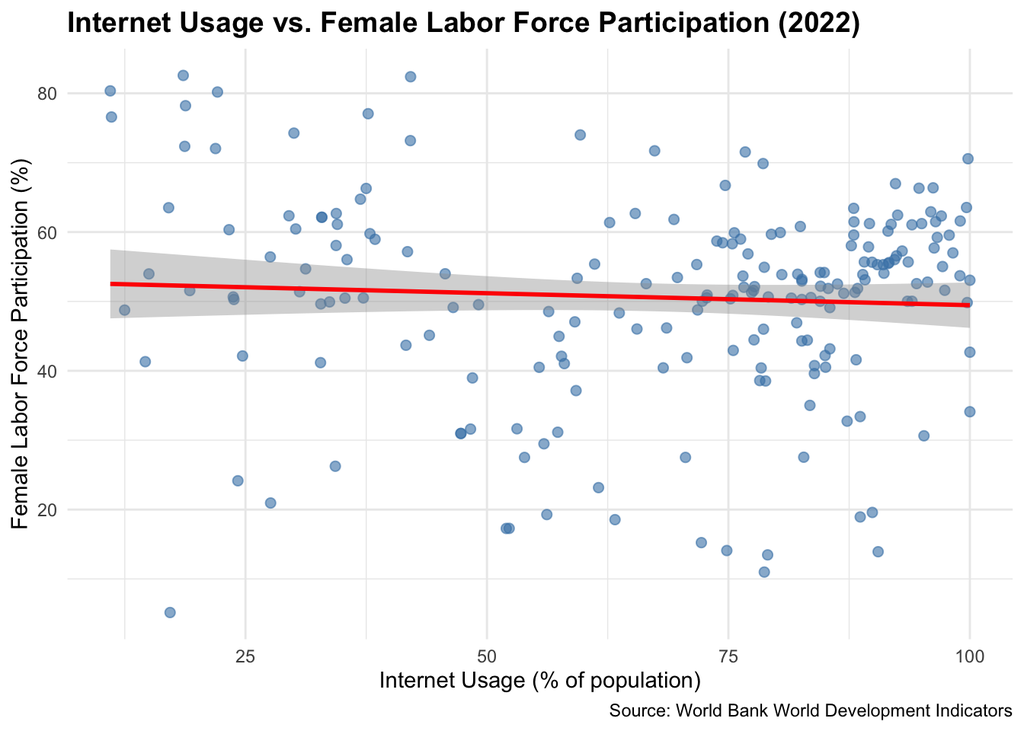

```r
ggplot(final_data, aes(x = internet_usage, y = female_labor_force)) +
  geom_point(alpha = 0.6, color = "steelblue", size = 2) +
  geom_smooth(method = "lm", col = "red", se = TRUE) + # "lm" stands for linear model
  labs(
    title = "Internet Usage vs. Female Labor Force Participation (2022)",
    x = "Internet Usage (% of population)",
    y = "Female Labor Force Participation (%)",
    caption = "Source: World Bank World Development Indicators"
  ) +
  theme_minimal() +
  theme(plot.title = element_text(face = "bold", size = 14))
```

**Interpretation:** The scatter plot reveals a nearly flat relationship between the two variables, consistent with the weak correlation coefficient. The red regression line has a slight negative slope, but the wide confidence interval (gray band) indicates high uncertainty. The plot shows substantial variation in female labor force participation even among countries with similar internet usage levels, suggesting that other factors beyond internet access are more important determinants of women’s workforce participation. We can see clusters of countries with high internet usage but varying levels of female participation (40-80%), which further supports that the relationship is not straightforward.

### Conclusion

This analysis examined the relationship between internet usage and female labor force participation across 203 countries in 2022. The data revealed several key findings:

**Key Findings:**

1. **Weak Negative Correlation:** The correlation coefficient of -0.06 indicates a very weak negative relationship between internet usage and female labor force participation. This suggests that, contrary to what might be expected, higher internet usage is not associated with increased female labor force participation at the country level.
2. **Internet Usage:** The average internet usage across countries was 67.7%, with a wide range from 11% to 100%. The median of 76.5% suggests that most countries have relatively high internet penetration.
3. **Female Labor Force Participation:** The average female labor force participation rate was 50.6%, ranging from 5.2% to 82.6%. This wide variation highlights significant global disparities in women’s workforce participation.

**Limitations and Future Research:**

- This analysis only captures a snapshot from 2022 and does not account for temporal trends or causality.
- Country-level aggregation may mask important within-country variations and regional differences.
- Other confounding factors such as cultural norms, economic development, education levels, and childcare availability were not considered.
- Future research could explore longitudinal data to understand how changes in internet access over time relate to changes in female labor force participation, and could include additional socioeconomic variables for a more comprehensive analysis.